[figure not shown]

## [Prof. Pedram Jahangiry](https://huntsman.usu.edu/directory/jahangiry-pedram)

# Linear Regression: Machine learning approach

A linear Regression is a **linear approximation** of a **relationship** between conditional expectations of two or more variables

First we need to import the libraries:

```python
import numpy as np
import pandas as pd
import matplotlib.pyplot as plt
import seaborn as sns
from sklearn.linear_model import LinearRegression  # (For machine learning approach we use sklearn package)
import statsmodels.api as sm # (For econometrics approach we use statsmodels package)

sns.set()  #if you want to use seaborn themes with matplotlib functions
```

```python
rand_state= 1000
```

```python
# let's import the Boston dataset from sklearn.datasets
from sklearn.datasets import load_boston
```

```python
boston = load_boston()
boston
```

[output not shown]

[output cut: 8 more lines]

[output not shown]

```python
dir(boston)
```

```
['DESCR', 'data', 'feature_names', 'filename', 'target']
```

```python
print(boston.DESCR)
```

```
.. _boston_dataset:

Boston house prices dataset
---------------------------

**Data Set Characteristics:**

    :Number of Instances: 506

    :Number of Attributes: 13 numeric/categorical predictive. Median Value (attribute 14) is usually the target.

    :Attribute Information (in order):
        - CRIM     per capita crime rate by town
        - ZN       proportion of residential land zoned for lots over 25,000 sq.ft.
        - INDUS    proportion of non-retail business acres per town
        - CHAS     Charles River dummy variable (= 1 if tract bounds river; 0 otherwise)
        - NOX      nitric oxides concentration (parts per 10 million)
        - RM       average number of rooms per dwelling
        - AGE      proportion of owner-occupied units built prior to 1940
        - DIS      weighted distances to five Boston employment centres
        - RAD      index of accessibility to radial highways
        - TAX      full-value property-tax rate per $10,000
        - PTRATIO  pupil-teacher ratio by town
        - B        1000(Bk - 0.63)^2 where Bk is the proportion of blacks by town
        - LSTAT    % lower status of the population
        - MEDV     Median value of owner-occupied homes in $1000's

    :Missing Attribute Values: None

    :Creator: Harrison, D. and Rubinfeld, D.L.

This is a copy of UCI ML housing dataset.
https://archive.ics.uci.edu/ml/machine-learning-databases/housing/


This dataset was taken from the StatLib library which is maintained at Carnegie Mellon University.

The Boston house-price data of Harrison, D. and Rubinfeld, D.L. 'Hedonic
prices and the demand for clean air', J. Environ. Economics & Management,
vol.5, 81-102, 1978.   Used in Belsley, Kuh & Welsch, 'Regression diagnostics
...', Wiley, 1980.   N.B. Various transformations are used in the table on
pages 244-261 of the latter.

The Boston house-price data has been used in many machine learning papers that address regression
problems.

.. topic:: References

   - Belsley, Kuh & Welsch, 'Regression diagnostics: Identifying Influential Data and Sources of Collinearity', Wiley, 1980. 244-261.
   - Quinlan,R. (1993). Combining Instance-Based and Model-Based Learning. In Proceedings on the Tenth International Conference of Machine Learning, 236-243, University of Massachusetts, Amherst. Morgan Kaufmann.
```

```python
print(boston.feature_names)
```

```
['CRIM' 'ZN' 'INDUS' 'CHAS' 'NOX' 'RM' 'AGE' 'DIS' 'RAD' 'TAX' 'PTRATIO'
 'B' 'LSTAT']
```

```python
type(boston.data)
```

```
numpy.ndarray
```

```python
df = pd.DataFrame(data=boston.data, columns=boston.feature_names)

# adding the targer variable
df['price']= boston.target
```

```python
df.head()
```

|  | CRIM | ZN | INDUS | CHAS | NOX | RM | AGE | DIS | RAD | TAX | PTRATIO | B | LSTAT | price |
| --- | --- | --- | --- | --- | --- | --- | --- | --- | --- | --- | --- | --- | --- | --- |
| 0 | 0.00632 | 18.0 | 2.31 | 0.0 | 0.538 | 6.575 | 65.2 | 4.0900 | 1.0 | 296.0 | 15.3 | 396.90 | 4.98 | 24.0 |
| 1 | 0.02731 | 0.0 | 7.07 | 0.0 | 0.469 | 6.421 | 78.9 | 4.9671 | 2.0 | 242.0 | 17.8 | 396.90 | 9.14 | 21.6 |
| 2 | 0.02729 | 0.0 | 7.07 | 0.0 | 0.469 | 7.185 | 61.1 | 4.9671 | 2.0 | 242.0 | 17.8 | 392.83 | 4.03 | 34.7 |
| 3 | 0.03237 | 0.0 | 2.18 | 0.0 | 0.458 | 6.998 | 45.8 | 6.0622 | 3.0 | 222.0 | 18.7 | 394.63 | 2.94 | 33.4 |
| 4 | 0.06905 | 0.0 | 2.18 | 0.0 | 0.458 | 7.147 | 54.2 | 6.0622 | 3.0 | 222.0 | 18.7 | 396.90 | 5.33 | 36.2 |

## Explanatory Data Analysis: EDA

```python
df.nunique()
```

```
CRIM       504
ZN          26
INDUS       76
CHAS         2
NOX         81
RM         446
AGE        356
DIS        412
RAD          9
TAX         66
PTRATIO     46
B          357
LSTAT      455
price      229
dtype: int64
```

```python
df.info()
```

```
<class 'pandas.core.frame.DataFrame'>
RangeIndex: 506 entries, 0 to 505
Data columns (total 14 columns):
CRIM       506 non-null float64
ZN         506 non-null float64
INDUS      506 non-null float64
CHAS       506 non-null float64
NOX        506 non-null float64
RM         506 non-null float64
AGE        506 non-null float64
DIS        506 non-null float64
RAD        506 non-null float64
TAX        506 non-null float64
PTRATIO    506 non-null float64
B          506 non-null float64
LSTAT      506 non-null float64
price      506 non-null float64
dtypes: float64(14)
memory usage: 55.4 KB
```

Since there is no NA values, we move on to the next step!

```python
df['RAD'].value_counts()
```

```
24.0    132
5.0     115
4.0     110
3.0      38
6.0      26
8.0      24
2.0      24
1.0      20
7.0      17
Name: RAD, dtype: int64
```

```python
df['CHAS'].value_counts()
```

```
0.0    471
1.0     35
Name: CHAS, dtype: int64
```

```python
df.describe().T
```

|  | count | mean | std | min | 25% | 50% | 75% | max |
| --- | --- | --- | --- | --- | --- | --- | --- | --- |
| CRIM | 506.0 | 3.613524 | 8.601545 | 0.00632 | 0.082045 | 0.25651 | 3.677083 | 88.9762 |
| ZN | 506.0 | 11.363636 | 23.322453 | 0.00000 | 0.000000 | 0.00000 | 12.500000 | 100.0000 |
| INDUS | 506.0 | 11.136779 | 6.860353 | 0.46000 | 5.190000 | 9.69000 | 18.100000 | 27.7400 |
| CHAS | 506.0 | 0.069170 | 0.253994 | 0.00000 | 0.000000 | 0.00000 | 0.000000 | 1.0000 |
| NOX | 506.0 | 0.554695 | 0.115878 | 0.38500 | 0.449000 | 0.53800 | 0.624000 | 0.8710 |
| RM | 506.0 | 6.284634 | 0.702617 | 3.56100 | 5.885500 | 6.20850 | 6.623500 | 8.7800 |
| AGE | 506.0 | 68.574901 | 28.148861 | 2.90000 | 45.025000 | 77.50000 | 94.075000 | 100.0000 |
| DIS | 506.0 | 3.795043 | 2.105710 | 1.12960 | 2.100175 | 3.20745 | 5.188425 | 12.1265 |
| RAD | 506.0 | 9.549407 | 8.707259 | 1.00000 | 4.000000 | 5.00000 | 24.000000 | 24.0000 |
| TAX | 506.0 | 408.237154 | 168.537116 | 187.00000 | 279.000000 | 330.00000 | 666.000000 | 711.0000 |
| PTRATIO | 506.0 | 18.455534 | 2.164946 | 12.60000 | 17.400000 | 19.05000 | 20.200000 | 22.0000 |
| B | 506.0 | 356.674032 | 91.294864 | 0.32000 | 375.377500 | 391.44000 | 396.225000 | 396.9000 |
| LSTAT | 506.0 | 12.653063 | 7.141062 | 1.73000 | 6.950000 | 11.36000 | 16.955000 | 37.9700 |
| price | 506.0 | 22.532806 | 9.197104 | 5.00000 | 17.025000 | 21.20000 | 25.000000 | 50.0000 |

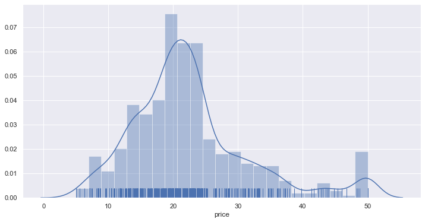

```python
plt.figure(figsize=(12,6))
sns.distplot(df['price'], rug=True)
plt.show()
```

**Exercise**: What do you infer from the distribution plot of the target variable? what should we do with that variable?

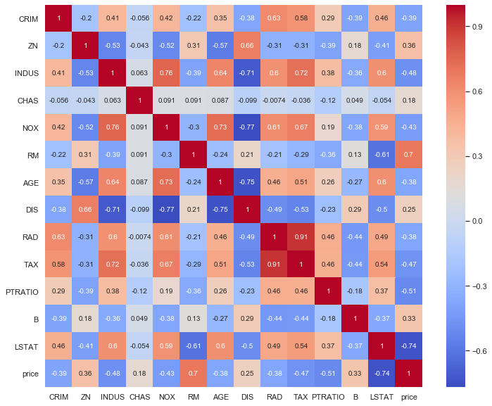

```python
plt.figure(figsize=(12,10))
sns.heatmap(df.corr(), cmap='coolwarm',annot=True)
plt.show()
```

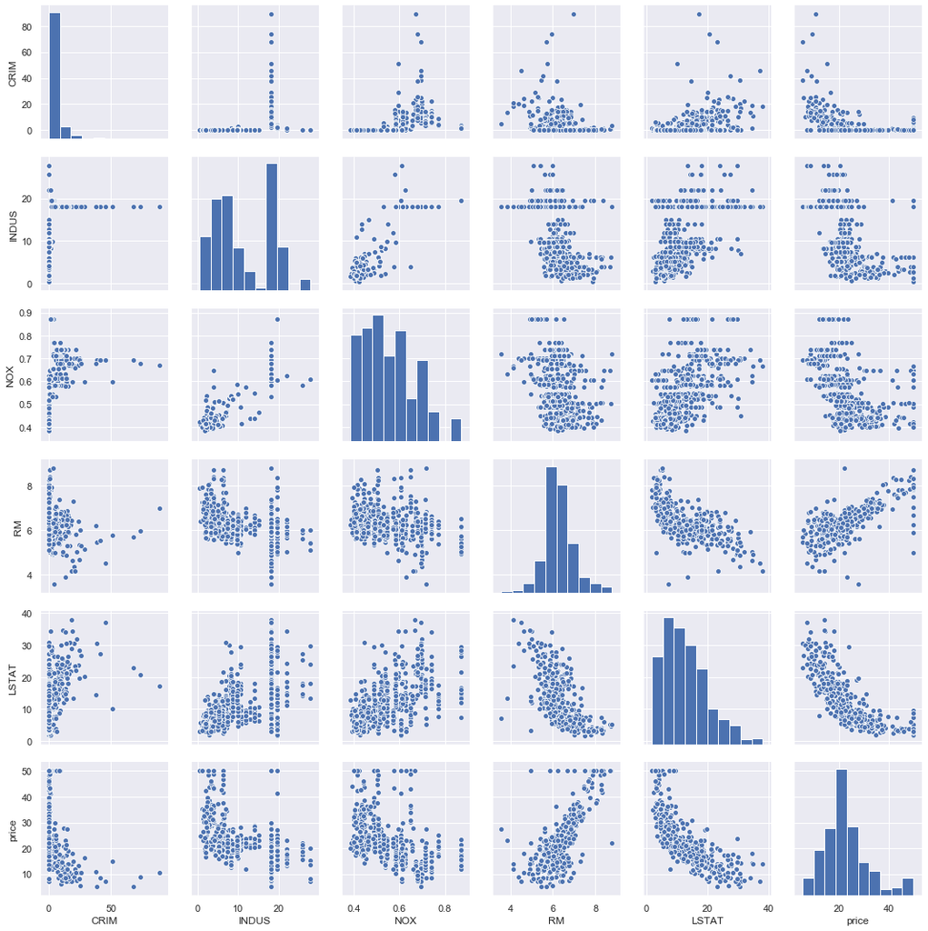

```
Wall time: 6.38 s
```

```python
%%time

sns.pairplot(df[['CRIM','INDUS','NOX','RM','LSTAT','price']])
plt.show()
```

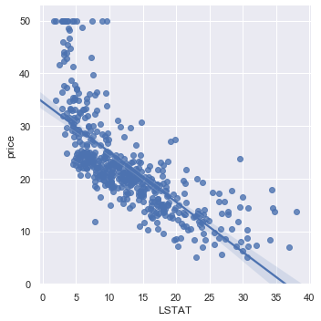

```python
g= sns.lmplot(x='LSTAT', y='price', data=df)
g.set(ylim=(0, None))
plt.show()
```

It seems that there is a non-linear relationship between price and LSTAT. We will explore this idea in our next lecture: Polynomial regression.

```python
#let's save this dataframe for our future exercises:
df.to_csv('boston_clean.csv',index=False)
```

### Train and Test set Split

```python
y = df['price']
X = df.drop('price', axis=1) # becareful inplace= False

from sklearn.model_selection import train_test_split
X_train, X_test, y_train, y_test = train_test_split(X, y, test_size=0.2, random_state=rand_state)

# checking the percentage of training set!
np.round(len(X_train)/len(X),3)
```

```
0.798
```

```python
X_train.head()
```

|  | CRIM | ZN | INDUS | CHAS | NOX | RM | AGE | DIS | RAD | TAX | PTRATIO | B | LSTAT |
| --- | --- | --- | --- | --- | --- | --- | --- | --- | --- | --- | --- | --- | --- |
| 300 | 0.04417 | 70.0 | 2.24 | 0.0 | 0.400 | 6.871 | 47.4 | 7.8278 | 5.0 | 358.0 | 14.8 | 390.86 | 6.07 |
| 32 | 1.38799 | 0.0 | 8.14 | 0.0 | 0.538 | 5.950 | 82.0 | 3.9900 | 4.0 | 307.0 | 21.0 | 232.60 | 27.71 |
| 181 | 0.06888 | 0.0 | 2.46 | 0.0 | 0.488 | 6.144 | 62.2 | 2.5979 | 3.0 | 193.0 | 17.8 | 396.90 | 9.45 |
| 272 | 0.11460 | 20.0 | 6.96 | 0.0 | 0.464 | 6.538 | 58.7 | 3.9175 | 3.0 | 223.0 | 18.6 | 394.96 | 7.73 |
| 477 | 15.02340 | 0.0 | 18.10 | 0.0 | 0.614 | 5.304 | 97.3 | 2.1007 | 24.0 | 666.0 | 20.2 | 349.48 | 24.91 |

## Linear Regression with Scikit-Learn

So far we have only worked with data frames using Pandas. Now we may need to transform our data into arrays by using numpy because sklearn uses arrays instead of data frames.

**Scikit-learn** is a very powerful package enabling you to do almost everything in machine learning including Regression, Classification, Clustering, SVM and Dimensionality reduction. However, I don't recommend sklearn for deep learning algorithms. Pytorch, Tensorflow and Keras are better alternatives for deep learning.

```python
reg_model = LinearRegression()
```

```python
reg_model.fit(X_train, y_train)
```

```
LinearRegression()
```

### Predictions:

```python
y_hat = reg_model.predict(X_test)
```

```python
df_predictions = pd.DataFrame({'actuals':y_test, 'predictions':y_hat, 'resid': y_test - y_hat})
df_predictions.head()
```

|  | actuals | predictions | resid |
| --- | --- | --- | --- |
| 483 | 21.8 | 21.287219 | 0.512781 |
| 426 | 10.2 | 17.231692 | -7.031692 |
| 22 | 15.2 | 15.500749 | -0.300749 |
| 268 | 43.5 | 39.403241 | 4.096759 |
| 371 | 50.0 | 25.382556 | 24.617444 |

### Coefficients:

try reg_model.

```python
# The coefficients of the regression
reg_model.coef_
```

```
array([-1.27947795e-01,  5.75316114e-02,  2.21875825e-03,  2.78683934e+00,
       -2.06744008e+01,  3.37509312e+00,  1.23545393e-04, -1.77457356e+00,
        3.11516569e-01, -1.08247434e-02, -1.05159118e+00,  8.40026939e-03,
       -5.05478185e-01])
```

```python
# The intercept of the regression
reg_model.intercept_
```

```
43.36838818964381
```

```python
# Let's create a new data frame with the names of the features
reg_summary = pd.DataFrame(data = X_train.columns, columns=['Features'])
reg_summary ['Coefficients'] = np.round(reg_model.coef_,4)
reg_summary
```

|  | Features | Coefficients |
| --- | --- | --- |
| 0 | CRIM | -0.1279 |
| 1 | ZN | 0.0575 |
| 2 | INDUS | 0.0022 |
| 3 | CHAS | 2.7868 |
| 4 | NOX | -20.6744 |
| 5 | RM | 3.3751 |
| 6 | AGE | 0.0001 |
| 7 | DIS | -1.7746 |
| 8 | RAD | 0.3115 |
| 9 | TAX | -0.0108 |
| 10 | PTRATIO | -1.0516 |
| 11 | B | 0.0084 |
| 12 | LSTAT | -0.5055 |

## Evaluation metrics:

One of the downsides of sklearn package is that, for linear regression models, the only built-in evaluation metric is R-squared (score). We need to mannually construct the other evaluation metrics like MSE, RMSE, adjusted R-squared, AIC, BIC, and etc.

Alternatively we could have used statsmodel package and get a nice summary table.

### R-squared

```python
# The train set R-squared of the regression
reg_model.score(X_train,y_train)
```

```
0.7484272373846235
```

```python
print('Training data R-squared:', np.round(reg_model.score(X_train, y_train),3))
print('Test data R-squared:', np.round(reg_model.score(X_test, y_test),3))
```

```
Training data R-squared: 0.748
Test data R-squared: 0.694
```

### Adjusted R-squared

```python
X_train.shape
```

```
(404, 13)
```

```python
def adj_R2(X,y):
    R2 = reg_model.score(X,y)
    n  = X.shape[0]
    k  = X.shape[1]
    return np.round(1-(1-R2)*(n-1)/(n-k-1),3)
```

```python
adj_R2(X_train,y_train)
```

```
0.74
```

```python
adj_R2(X_test,y_test)
```

```
0.649
```

### MSE and RMSE

This is the most common metric used for comparing linear regression models!

```python
df_predictions.head()
```

|  | actuals | predictions | resid |
| --- | --- | --- | --- |
| 483 | 21.8 | 21.287219 | 0.512781 |
| 426 | 10.2 | 17.231692 | -7.031692 |
| 22 | 15.2 | 15.500749 | -0.300749 |
| 268 | 43.5 | 39.403241 | 4.096759 |
| 371 | 50.0 | 25.382556 | 24.617444 |

```python
MSE_test = np.mean(np.square(df_predictions['resid']))
np.round(MSE_test,3)
```

```
26.082
```

```python
RMSE_test = np.sqrt(MSE_test)
np.round(RMSE_test,3)
```

```
5.107
```

## Cross Validation

Estimating the test set evaluation metrics using cross validation! Remember, we are interested in model performance in the test set not train set!!

```python
from sklearn.model_selection import cross_val_score
import sklearn.metrics
```

```python
# What metrics are available for cross validation in sklearn?
sorted(sklearn.metrics.SCORERS.keys())
```

```
['accuracy',
 'adjusted_mutual_info_score',
 'adjusted_rand_score',
 'average_precision',
 'balanced_accuracy',
 'completeness_score',
 'explained_variance',
 'f1',
 'f1_macro',
 'f1_micro',
 'f1_samples',
 'f1_weighted',
 'fowlkes_mallows_score',
 'homogeneity_score',
 'jaccard',
 'jaccard_macro',
 'jaccard_micro',
 'jaccard_samples',
 'jaccard_weighted',
 'max_error',
 'mutual_info_score',
 'neg_brier_score',
 'neg_log_loss',
 'neg_mean_absolute_error',
 'neg_mean_absolute_percentage_error',
 'neg_mean_gamma_deviance',
 'neg_mean_poisson_deviance',
 'neg_mean_squared_error',
 'neg_mean_squared_log_error',
 'neg_median_absolute_error',
 'neg_root_mean_squared_error',
 'normalized_mutual_info_score',
 'precision',
 'precision_macro',
 'precision_micro',
 'precision_samples',
 'precision_weighted',
 'r2',
 'rand_score',
 'recall',
 'recall_macro',
 'recall_micro',
 'recall_samples',
 'recall_weighted',
 'roc_auc',
 'roc_auc_ovo',
 'roc_auc_ovo_weighted',
 'roc_auc_ovr',
 'roc_auc_ovr_weighted',
 'top_k_accuracy',
 'v_measure_score']
```

```python
my_estimator = LinearRegression()
```

```python
R2 = cross_val_score(estimator=my_estimator, X=X_train, y=y_train, cv=5, scoring="r2")
```

```python
R2
```

```
array([0.64095259, 0.70188733, 0.69301675, 0.76382877, 0.73940009])
```

```python
R2_CV = np.mean(R2)
np.round(R2_CV,3)
```

```
0.708
```

This is the estimated version of $R^2_{test}$ which was about 0.694!

```python
NMSE = cross_val_score(estimator=my_estimator, X=X_train, y=y_train, cv=10, scoring="neg_mean_squared_error")
```

```python
MSE= -NMSE
MSE
```

```
array([33.49363219, 14.83051734, 20.95423932, 37.4838053 ,  9.84442331,
       24.5197077 , 13.88734797, 19.11258971, 25.99127302, 32.48326402])
```

```python
MSE_CV = np.mean(MSE)
np.round(MSE_CV,3)
```

```
23.26
```

This is the estimated version of **MSE_test** which was about 26.082!

```python
RMSE = np.sqrt(MSE)
RMSE
```

```
array([5.78736833, 3.85104107, 4.57758007, 6.12240192, 3.1375824 ,
       4.95173785, 3.72657322, 4.37179479, 5.09816369, 5.69940909])
```

```python
RMSE_CV = np.mean(RMSE)
np.round(RMSE_CV,3)
```

```
4.732
```

This is the estimated version of **RMSE_test** which was about 5.107!

**DONE!**

We usually stop here for Machine Learning Linear Regression analysis. However, if you need to report more evaluation metrics, it would be much easier to use statsmodel package. Statsmodel is great for **interpretation aspect** of linear regression models. Also Statsmodel works perfectly with pandas dataframe. However, sklearn is a more **practical** package preferred by ML practicitionairs to apply regression analysis. If you want to know more about the details, refer to the additional link at the end of this notebook.

```python
import statsmodels.api as sm
```

```python
# With statsmodels, we need to mannually add a constant to our dataset!
X_test_wc = sm.add_constant(X_test)
X_train_wc = sm.add_constant(X_train)
```

```python
X_train_wc.head()
```

|  | const | CRIM | ZN | INDUS | CHAS | NOX | RM | AGE | DIS | RAD | TAX | PTRATIO | B | LSTAT |
| --- | --- | --- | --- | --- | --- | --- | --- | --- | --- | --- | --- | --- | --- | --- |
| 300 | 1.0 | 0.04417 | 70.0 | 2.24 | 0.0 | 0.400 | 6.871 | 47.4 | 7.8278 | 5.0 | 358.0 | 14.8 | 390.86 | 6.07 |
| 32 | 1.0 | 1.38799 | 0.0 | 8.14 | 0.0 | 0.538 | 5.950 | 82.0 | 3.9900 | 4.0 | 307.0 | 21.0 | 232.60 | 27.71 |
| 181 | 1.0 | 0.06888 | 0.0 | 2.46 | 0.0 | 0.488 | 6.144 | 62.2 | 2.5979 | 3.0 | 193.0 | 17.8 | 396.90 | 9.45 |
| 272 | 1.0 | 0.11460 | 20.0 | 6.96 | 0.0 | 0.464 | 6.538 | 58.7 | 3.9175 | 3.0 | 223.0 | 18.6 | 394.96 | 7.73 |
| 477 | 1.0 | 15.02340 | 0.0 | 18.10 | 0.0 | 0.614 | 5.304 | 97.3 | 2.1007 | 24.0 | 666.0 | 20.2 | 349.48 | 24.91 |

```python
# Fit the model
model = sm.OLS(y_train,X_train_wc)
statsmodels_reg= model.fit()
```

```python
statsmodels_reg.summary()
```

OLS Regression Results

| Dep. Variable: | price | R-squared: | 0.748 |
| --- | --- | --- | --- |
| Model: | OLS | Adj. R-squared: | 0.740 |
| Method: | Least Squares | F-statistic: | 89.25 |
| Date: | Wed, 10 Feb 2021 | Prob (F-statistic): | 4.14e-108 |
| Time: | 23:15:19 | Log-Likelihood: | -1189.9 |
| No. Observations: | 404 | AIC: | 2408. |
| Df Residuals: | 390 | BIC: | 2464. |
| Df Model: | 13 |  |  |
| Covariance Type: | nonrobust |  |  |

|  | coef | std err | t | P>\|t\| | [0.025 | 0.975] |
| --- | --- | --- | --- | --- | --- | --- |
| const | 43.3684 | 5.725 | 7.576 | 0.000 | 32.113 | 54.624 |
| CRIM | -0.1279 | 0.034 | -3.811 | 0.000 | -0.194 | -0.062 |
| ZN | 0.0575 | 0.015 | 3.858 | 0.000 | 0.028 | 0.087 |
| INDUS | 0.0022 | 0.067 | 0.033 | 0.974 | -0.130 | 0.134 |
| CHAS | 2.7868 | 0.899 | 3.099 | 0.002 | 1.019 | 4.555 |
| NOX | -20.6744 | 4.076 | -5.072 | 0.000 | -28.688 | -12.661 |
| RM | 3.3751 | 0.460 | 7.341 | 0.000 | 2.471 | 4.279 |
| AGE | 0.0001 | 0.015 | 0.008 | 0.993 | -0.029 | 0.029 |
| DIS | -1.7746 | 0.227 | -7.805 | 0.000 | -2.222 | -1.328 |
| RAD | 0.3115 | 0.073 | 4.283 | 0.000 | 0.169 | 0.455 |
| TAX | -0.0108 | 0.004 | -2.639 | 0.009 | -0.019 | -0.003 |
| PTRATIO | -1.0516 | 0.141 | -7.475 | 0.000 | -1.328 | -0.775 |
| B | 0.0084 | 0.003 | 2.818 | 0.005 | 0.003 | 0.014 |
| LSTAT | -0.5055 | 0.054 | -9.382 | 0.000 | -0.611 | -0.400 |

| Omnibus: | 124.298 | Durbin-Watson: | 1.948 |
| --- | --- | --- | --- |
| Prob(Omnibus): | 0.000 | Jarque-Bera (JB): | 440.531 |
| Skew: | 1.357 | Prob(JB): | 2.19e-96 |
| Kurtosis: | 7.337 | Cond. No. | 1.52e+04 |

Warnings:  
[1] Standard Errors assume that the covariance matrix of the errors is correctly specified.  
[2] The condition number is large, 1.52e+04. This might indicate that there are  
strong multicollinearity or other numerical problems.

#### Additional links:

1. Statsmodel vs Sklearn: https://medium.com/@hsrinivasan2/linear-regression-in-scikit-learn-vs-statsmodels-568b60792991
2. Interpreting the statsmodel output! https://www.accelebrate.com/blog/interpreting-results-from-linear-regression-is-the-data-appropriate